# IMAGE CLASSIFICATION

[figure not shown]

# Business Problem:

## Description:

Ship or vessel detection has a wide range of applications, in the areas of maritime safety, fisheries management, marine pollution, defence and maritime security, protection from piracy, illegal migration, etc.

Keeping this in mind, a Governmental Maritime and Coastguard Agency is planning to deploy a computer vision based automated system to identify ship type only from the images taken by the survey boats. You have been hired as a consultant to build an efficient model for this project.

# Dataset Description

### There are 6252 images in train and 2680 images in test data. The categories of ships and their corresponding codes in the dataset are as follows -

#### There are 5 classes of ships to be detected which are as follows:

## Cargo------------------->>> Class label 1

## Military----------------->>> Class label 2

## Carrier------------------>>> Class label 3

## Cruise------------------>>> Class label 4

## Tankers---------------->>> Class label 5

#### This dataset was in the Analytics Vidhya contest i.e GAME OF DEEP LEARNING https://datahack.analyticsvidhya.com/contest/game-of-deep-learning/ which was computer vision hackathon from 25th/may/19 to 10th/June/19.

## Problem Statemtent:

#### To predict the class label y i.e predect catagory of image(Class label) is Cargo,Military,Carrier,Cruise or Tankers .

# Evaluation Metric:

#### Weighted F1 score:----------->>> The F1 Scores are calculated for each label and then their average is weighted by support - which is the number of true instances for each label. It can result in an F-score that is not between precision and recall.

https://en.wikipedia.org/wiki/F1_score https://scikit-learn.org/stable/modules/generated/sklearn.metrics.f1_score.html

# Real World / Business Objectives and Constraints:

###### 1---->> Predect the class label of images with high Weighted F1 score.

###### 2---->> No strict latency constraints.

### HERE WE HAVE MADE THIS CASE CASE STUDY ON ONLY 6252 images which is further spilit into train and test.

### Importing libraries:

```python
import keras
from keras.models import Sequential
from keras.layers import Dense, Dropout, Flatten
from keras.layers import Conv2D, MaxPooling2D
from keras.utils import to_categorical
from keras.preprocessing import image
import numpy as np
import pandas as pd
import matplotlib.pyplot as plt
from sklearn.model_selection import train_test_split
from tqdm import tqdm
%matplotlib inline
from keras.models import Sequential
from scipy.misc import imread
get_ipython().magic('matplotlib inline')
import matplotlib.pyplot as plt
import numpy as np
import keras
from keras.layers import Dense
import pandas as pd

#from keras.applications.vgg16 import VGG16
from keras.preprocessing import image
from keras.applications.vgg16 import preprocess_input
import numpy as np
#from keras.applications.vgg16 import decode_predictions
from keras.utils.np_utils import to_categorical

from sklearn.preprocessing import LabelEncoder
from keras.models import Sequential
from keras.optimizers import SGD
from keras.layers import Input, Dense, Convolution2D, MaxPooling2D, AveragePooling2D, ZeroPadding2D, Dropout, Flatten, merge, Reshape, Activation
from keras.layers.normalization import BatchNormalization
from sklearn.metrics import log_loss
import matplotlib.pyplot as plt
import seaborn as sns

# Python program to read
# image using matplotlib

# importing matplotlib modules
import matplotlib.image as mpimg
import matplotlib.pyplot as plt
```

```python
# this will do preprocessing and realtime data augmentation
'''from keras.preprocessing.image import ImageDataGenerator
from keras.layers.normalization import BatchNormalization
datagen = ImageDataGenerator(
    featurewise_center=False,  # set input mean to 0 over the dataset
    samplewise_center=False,  # set each sample mean to 0
    featurewise_std_normalization=False,  # divide inputs by std of the dataset
    samplewise_std_normalization=False,  # divide each input by its std
    zca_whitening=False,  # apply ZCA whitening
    rotation_range=25,  # randomly rotate images in the range (degrees, 0 to 180)
    width_shift_range=0.1,  # randomly shift images horizontally (fraction of total width)
    height_shift_range=0.1,  # randomly shift images vertically (fraction of total height)
    horizontal_flip=True,  # randomly flip images
    vertical_flip=False)  # randomly flip images

datagen.fit(train_img)'''
```

# SOME EDA ON DATA:

```python
X_train[2].shape
```

```
(139, 210, 3)
```

```python
train.head(10)
```

|  | image | category |
| --- | --- | --- |
| 0 | 2823080.jpg | 1 |
| 1 | 2870024.jpg | 1 |
| 2 | 2662125.jpg | 2 |
| 3 | 2900420.jpg | 3 |
| 4 | 2804883.jpg | 2 |
| 5 | 621252.jpg | 4 |
| 6 | 2833467.jpg | 1 |
| 7 | 2843780.jpg | 5 |
| 8 | 2859567.jpg | 3 |
| 9 | 2896557.jpg | 1 |

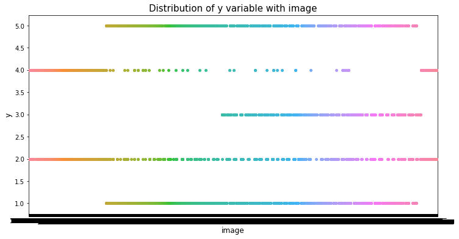

```python
var_name = "image"
col_order = np.sort(train[var_name].unique()).tolist()
plt.figure(figsize=(12,6))
sns.stripplot(x=var_name, y='category', data=train, order=col_order)
plt.xlabel(var_name, fontsize=12)
plt.ylabel('y', fontsize=12)
plt.title("Distribution of y variable with "+var_name, fontsize=15)
plt.show()
```

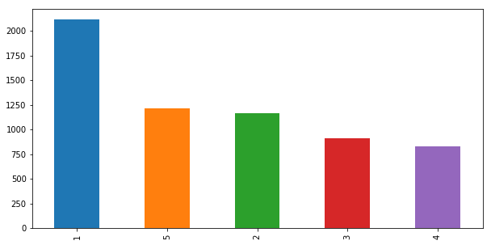

```python
fig, ax1 = plt.subplots(1, 1, figsize= (10, 5))
train['category'].value_counts().plot(kind='bar', ax=ax1)
```

#### OBSERVATION: HERE WE CAN OBSERVE THAT IMAGES WITH CLASS 1 IS MAJORITY I.E HAVING MORE NO. OF POINTS AS COMPAIR TO OTHER CLASSES, REST ALL OTHER CLASS HAVING BALANCED NO OF LABELS

# Cargo Class Label 1

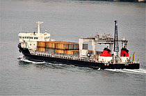

```python
image.load_img(train_path+train['image'][1])
```

# Military Class Label 2

```python
image.load_img(train_path+train['image'][2])
```

[output not shown]

# Carrier Class Label 3

```python
image.load_img(train_path+train['image'][3])
```

[output not shown]

# Cruise Class Label 4

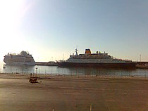

```python
image.load_img(train_path+train['image'][5])
```

# Tankers Class Label 5

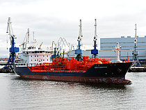

```python
image.load_img(train_path+train['image'][7])
```

# DATA PREPROCESSING i.e CONVERTING IMAGES INTO ARRAYES:

```python
train=pd.read_csv("train.csv")
test=pd.read_csv("test_ApKoW4T.csv")
train_path="images/"
test_path="images/"

from scipy.misc import imresize

train_img=[]
for i in range(len(train)):

    temp_img=image.load_img(train_path+train['image'][i],target_size=(139, 210))

    temp_img=image.img_to_array(temp_img)

    train_img.append(temp_img)

#converting train images to array and applying mean subtraction processing

train_img=np.array(train_img)
train_img=preprocess_input(train_img)
# applying the same procedure with the test dataset

test_img=[]
for i in range(len(test)):

    temp_img=image.load_img(test_path+test['image'][i],target_size=(139, 210))

    temp_img=image.img_to_array(temp_img)

    test_img.append(temp_img)

test_img=np.array(test_img)
test_img=preprocess_input(test_img)



train_y=np.asarray(train['category'])
# performing one-hot encoding for the target variable

train_y=pd.get_dummies(train_y)
train_y=np.array(train_y)
# creating training and validation set
```

# Splitting data into Train(85%) and Test(15%):

```python
from sklearn.model_selection import train_test_split
X_train, X_valid, Y_train, Y_valid=train_test_split(train_img,train_y,test_size=0.15, random_state=42)
```